# **Facial Emotion Detection**

## **About the dataset**

The data set consists of 3 folders, i.e., 'test', 'train', and 'validation'. Each of these folders has four subfolders:

**‘happy’**: Images of people who have happy facial expressions.  
**‘sad’**: Images of people with sad or upset facial expressions.  
**‘surprise’**: Images of people who have shocked or surprised facial expressions.  
**‘neutral’**: Images of people showing no prominent emotion in their facial expression at all.

## **Mounting the Drive**

```python
# Mounting the drive
from google.colab import drive
drive.mount('/content/drive')
```

## **Importing the Libraries**

```python
import zipfile
import matplotlib.pyplot as plt
import numpy as np
import pandas as pd
import seaborn as sns
import os
import tensorflow as tf

# Importing Deep Learning Libraries

from tensorflow.keras.preprocessing.image import load_img, img_to_array
from tensorflow.keras.preprocessing.image import ImageDataGenerator
from tensorflow.keras.layers import Dense, Input, Dropout, GlobalAveragePooling2D, Flatten, Conv2D, BatchNormalization, Activation, MaxPooling2D, LeakyReLU
from tensorflow.keras.models import Model, Sequential
from tensorflow.keras.optimizers import Adam, SGD, RMSprop
```

### **Loading Data**

```python
# Storing the path of the data file from the Google drive
path = '/content/drive/MyDrive/1DS/MIT ADSP/Capstone Project/Facial_emotion_images.zip'

# The data is provided as a zip file so we need to extract the files from the zip file
with zipfile.ZipFile(path, 'r') as zip_ref:
    zip_ref.extractall()
```

```python
picture_size = 48
folder_path = "Facial_emotion_images/"
```

## **Visualizing our Classes**

### **Happy**

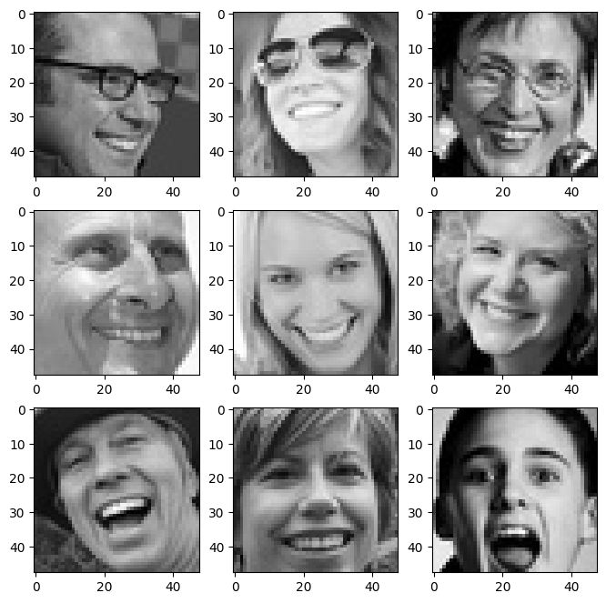

```python
# Code to visualize images from the class 'happy'.
expression = 'happy'

plt.figure(figsize= (8,8))
for i in range(1, 10, 1):
    plt.subplot(3, 3, i)

    img = load_img(folder_path + "train/" + expression + "/" +
                  os.listdir(folder_path + "train/" + expression)[i], target_size = (picture_size, picture_size))
    plt.imshow(img)

plt.show()
```

**Observations and Insights:**

- Most of them show teeth, though one does not.
- Brows/eyes are all concave down, while mouths are for the most part concave up.

### **Sad**

[figure not shown]

```python
# Code to visualize images from the class 'sad'.
expression2 = 'sad'

plt.figure(figsize= (8,8))
for i in range(1, 10, 1):
    plt.subplot(3, 3, i)

    img = load_img(folder_path + "train/" + expression2 + "/" +
                  os.listdir(folder_path + "train/" + expression2)[i], target_size = (picture_size, picture_size))
    plt.imshow(img)

plt.show()
```

**Observations and Insights:**

- Mouths/Eyes are concave down or flat
- There seem to be cartoonish drawing instead of a human picture.